# ase analyses of SC males

### Data cleaning

#### SC male DNA and RNA

aligned to hap 2 reference, reads counted using GATK ASEreadcounter

#### mutate (make variant ID), filter, combine

For (possibly predictable) reasons, the ASEReadcounter output for DNA misses some low read-depth but confidently called heterozygous snps. This results in some 0’s in the refCount, altCount, and total count categories in the DNA counts file - which is not expected. option - sanity checking with the snps I have, getting depths from the vcf directly, etc.etc

```r
dnacountsraw <- mutate(dnacountsraw, variantID = str_c(contig,'_',position)) #
```

### Reference bias

mean rnarefratio is 0.570816, mean dnarefratio is 0.5432586 slightly higher than with previous genome assembly version ### site-wise statistical tests for ASE fisher test to see if DNA refratio is sig diff from that of RNA binomial test for ase

```r
# called counts
# and then turn rna,dna, alt, ref into separate categories?
#combocounts %>% select(refCount_dna,altCount_dna,refCount_rna,altCount_rna)
fisher <- function(a,b,c,d){
  data <- matrix(c(a,b,c,d),ncol=2)
  c(p = fisher.test(data)$p.value) #odds ratio estimate
}
bt <- function(a, b, p = 0.5) {binom.test(a, b, 0.5, alternative=
                                            c("two.sided"), conf.level = 0.95)$p.value}

# positions of sex linked regions
combocounts_sl<-combocounts %>% mutate(contig = factor(contig, levels = c("A1","A2","A4","Y1","Y2"))) %>%
  mutate(sexlink = case_when(
    (contig == 'Y1' & position > 64000000 & position < 272000000) ~ 'OldSLR',
    (contig == 'Y1' & position > 272000000) ~ 'PAR1',
    (contig == 'Y2' & position > 159000000) ~ 'OldSLR',
    (contig == 'Y1' & position < 64000000) ~ 'NewSLR',
    (contig == 'Y2' & position >121000000 & position <159000000 )  ~ 'NewSLR',
    (contig == 'Y2' & position < 121000000) ~ 'PAR2',
    contig == 'A1' ~ 'A1',
    contig == 'A2' ~ 'A2',
    contig == 'A4' ~ 'A4',
    ))

#View(select(pvals, refCount_rna,altCount_rna, refCount_dna,altCount_dna,p))
gc()
```

```
            used  (Mb) gc trigger   (Mb) limit (Mb)  max used   (Mb)
Ncells   9824992 524.8   24906124 1330.2         NA  17927400  957.5
Vcells 121920112 930.2  282610926 2156.2      16384 235175472 1794.3
```

```r
pvals <- combocounts_sl %>%
  rowwise() %>%
  mutate(pfisher=fisher(refCount_dna,altCount_dna,refCount_rna,altCount_rna)[[1]]) %>%
  mutate(pbinom=bt(refCount_rna,totalCount_rna)) #%>% ## FDR?
pvals<- pvals %>% mutate(.,pfisherBH = (p.adjust(pfisher,"BH",n=length(pvals$pfisher)))) %>%
  mutate(.,pbinomBH = (p.adjust(pbinom,"BH",n=length(pvals$pbinom))))
#apply benjaminin hochberg correction R
nrow(filter(pvals, pfisherBH<0.05,pbinomBH<0.05)) # 6986
```

```
[1] 6986
```

```r
nrow(filter(pvals, pbinomBH<0.05)) #22878
```

```
[1] 22878
```

```r
sigtest<- pvals %>% filter(pfisherBH<0.05) %>% filter(pbinomBH<0.05) %>%
  group_by(contig,sitetype) %>% summarise(n_sig = n())
#just_binom <- pvals %>% filter(pbinomBH<0.05) %>%
#  group_by(contig,sitetype) %>% summarise(n_sig = n())
totalnum <- pvals %>% group_by(contig) %>% summarise(n_all= n())
#mutate(propn, prop = n_sig/n_all)
#totalnum <- group_by(snplist, CHROM) %>% summarise(n=n()) %>% arrange(.,desc(n))
propn<- left_join(sigtest, totalnum, by = c("contig")) %>% mutate(., prop = n_sig/n_all)
#vroom_write(pvals, "sc_male_ase_sigtests.csv",",")
# fisher and binom test
sigtest_sl<- pvals %>% filter(pfisherBH<0.05) %>% filter(pbinomBH<0.05) %>%
  group_by(sexlink,sitetype) %>% summarise(n_sig = n())
totalnum_sl <- pvals %>% group_by(sexlink) %>% summarise(n_all= n())
propn_sl <- left_join(sigtest_sl,totalnum_sl, by = c("sexlink")) %>%
  mutate(., prop = n_sig/n_all)
print(propn_sl)
```

| sexlink | sitetype | n_sig | n_all | prop |
| --- | --- | --- | --- | --- |
| A1 | altoverexp | 195 | 22457 | 0.008683261 |
| A1 | altsilence | 784 | 22457 | 0.034911164 |
| A1 | refoverexp | 389 | 22457 | 0.017321993 |
| A1 | refsilence | 357 | 22457 | 0.015897048 |
| A2 | altoverexp | 72 | 20564 | 0.003501264 |
| A2 | altsilence | 677 | 20564 | 0.032921611 |
| A2 | refoverexp | 260 | 20564 | 0.012643455 |
| A2 | refsilence | 171 | 20564 | 0.008315503 |
| A4 | altoverexp | 69 | 10452 | 0.006601607 |
| A4 | altsilence | 428 | 10452 | 0.040949101 |

[output cut: 18 more lines]

```r
## just the binom test
sigtest_binom<- pvals %>% filter(pbinomBH<0.05) %>%
  group_by(sexlink,sitetype) %>% summarise(n_sig = n())
totalnum_sl <- pvals %>% group_by(sexlink) %>% summarise(n_all= n())
propn_binom <- left_join(sigtest_binom,totalnum_sl, by = c("sexlink")) %>%
  mutate(., prop = n_sig/n_all)
#vroom_write(pvals, "sigtable.txt")
```

### beta-binomial test?

```r
#countdata::bb.test()

#bb <- function(a, b, p = 0.5) {bb.test(a, b, 0.5, alternative=
                                            c("two.sided"))$p.value}
```

```
Error: unexpected ')' in "                                            c("two.sided"))"
```

### Analyses

#### to do

- sig snp in gene = gene has sig ASE - count only once
- repeat w hap1, use liftover/ortho list
- later - snps, anno TEs, connect to genes, etc. -e..g median/mean across genes or something This table is just the number of ASE sites where there is significant departure b/w the dna and rna w respect to alt and ref read counts. Need to filter a bit more probably. Plotting ASE vs contig to get a better idea of whats going on here.
- denom for propn should be snps after filtering but before sign #### getting total counts for proportions of sig sites

```r
#myvcf<-read.vcfR("scf2m12_dna_noindelsqual60_hap2.recode.vcf.gz")
#snpnum<-myvcf@fix %>% group_by(CHROM) %>% summarise()
#myvcfdf <- as.data.frame(myvcf@fix)
#rm(myvcf)
#head(myvcfdf)
#snplist<-select(myvcfdf, CHROM,POS)
#vroom_write(snplist, "snplist.txt", delim = "\t", col_names = TRUE)
#snplist<-vroom("snplist.txt")
#rm(snplisttest)
#group_by(snplist, CHROM) %>% summarise(n=n()) %>% arrange(.,desc(n))
```

#### exploratory plots

DNA read count distributions

- Settled on 60 as a max read count.

```r
## plot total DNA counts to see if a "max" read count is useful at all
# ggplot(pvals, aes(totalCount_dna)) + geom_histogram(binwidth=5) + xlim(0,60) # removes 867 rows
#ggplot(pvals, aes(totalCount_dna)) + geom_histogram(binwidth=5)
# md <-mean(pvals$totalCount_dna)
# mean(pvals$totalCount_dna)
# median(pvals$totalCount_dna)
# max(pvals$totalCount_dna)
# min(pvals$totalCount_dna)
#
# # https://academic.oup.com/bioinformatics/article/30/20/2843/2422145
# # Each chosen threshold yields a point in the plot. An arrow points to a point on the MD curve when the corresponding read depth is right above d+4d‾‾√ , where d is the mean read depth across called variants
# #maxdepth <- md + (4*sqrt(md))
# #maxdepth # 51
# # not sure i like this cutoff... much to think about
# ## orr... I should go to the vcf maybe
# #"Usually a good rule of thumb is something the mean depth x 2 - so in this case we could set our maximum depth at 40x." - https://speciationgenomics.github.io/filtering_vcfs/
# maxdepth <- md*2
# maxdepth # 59? - maybe try from the vcf...
# #md 60
#
# ggplot(pvals_md, aes(totalCount_dna)) + geom_histogram(binwidth=5) + xlim(0,60) # removes 867 rows
# ggplot(pvals_md, aes(totalCount_dna)) + geom_histogram(binwidth=5)
# #md <-mean(pvals$totalCount_dna)
# mean(pvals_md$totalCount_dna)
# median(pvals_md$totalCount_dna)
# max(pvals_md$totalCount_dna)
# min(pvals_md$totalCount_dna)
#
# propn<- left_join(sigtest, totalnum, by = c("contig"="contig")) %>% mutate(., prop = n_sig/n_all)
```

RNA ref ratio

- not filtered by significance
- lower ratios in Y1, reference bias everywhere else, no significant diff b/w groups

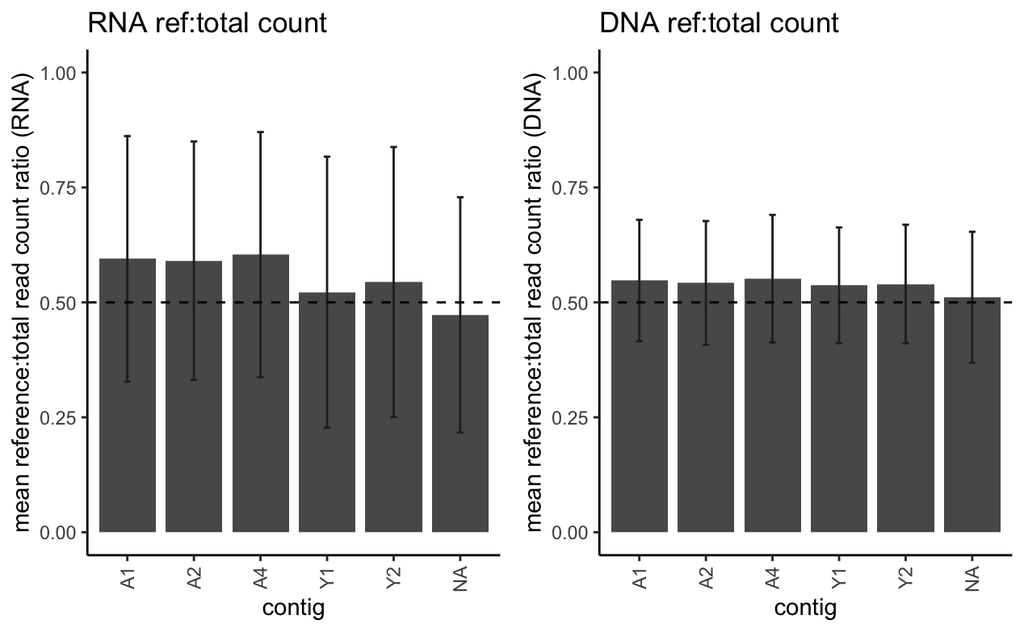

RNA vs DNA refratio - by sex linked region

- Old Sex linked region has most obvious dip in mean ase

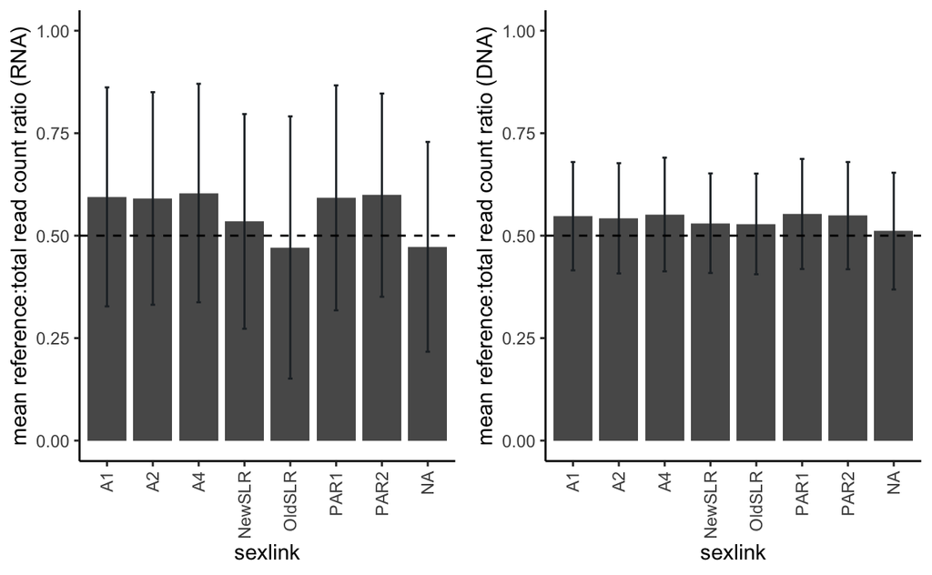

```r
ase_df_sl<- pvals %>% #filter(pfisherBH<0.05 & pbinomBH<0.05)
   group_by(sexlink) %>%
    summarise(mean_ase = mean(rnarefratio),
  sd_ase=sd(rnarefratio))

rna_ase_sl<-ggplot(ase_df_sl,aes(sexlink, mean_ase)) +
    geom_col(width = 0.85) +
    geom_errorbar(aes(ymin = mean_ase - sd_ase,
                      ymax = mean_ase + sd_ase),
                  color = "#22292F",
                  width = .1) +
   theme_classic() +  theme(axis.text.x = element_text(angle = 90, vjust = 0.5, hjust=1)) +
   ylab("mean reference:total read count ratio (RNA)") + geom_hline(yintercept=0.5, linetype="dashed") + ylim(0,1)
#ggsave("asemean_all_rna_sex.png", height=5,width=7)

 ase_df_dna_sl<- pvals %>% #filter(pfisherBH<0.05 & pbinomBH<0.05)
   group_by(sexlink) %>%
    summarise(mean_ase = mean(dnarefratio),
  sd_ase=sd(dnarefratio))
dna_ase_sl<-ggplot(ase_df_dna_sl,aes(sexlink, mean_ase)) +
    geom_col(width = 0.85) +
    geom_errorbar(aes(ymin = mean_ase - sd_ase,
                      ymax = mean_ase + sd_ase),
                  color = "#22292F",
                  width = .1) +
   theme_classic() +  theme(axis.text.x = element_text(angle = 90, vjust = 0.5, hjust=1)) +
   ylab("mean reference:total read count ratio (DNA)") + geom_hline(yintercept=0.5, linetype="dashed") + ylim(0,1)
#ggsave("asemean_all_dna_sex.png", height=5,width=7)
cowplot::plot_grid(rna_ase_sl,dna_ase_sl)
```

#### plot signifiance ase proportions per chromosome/region

By chromosome

- Y1 and Y2 have elevated ref (Y) silencing, alt (X) overexpression

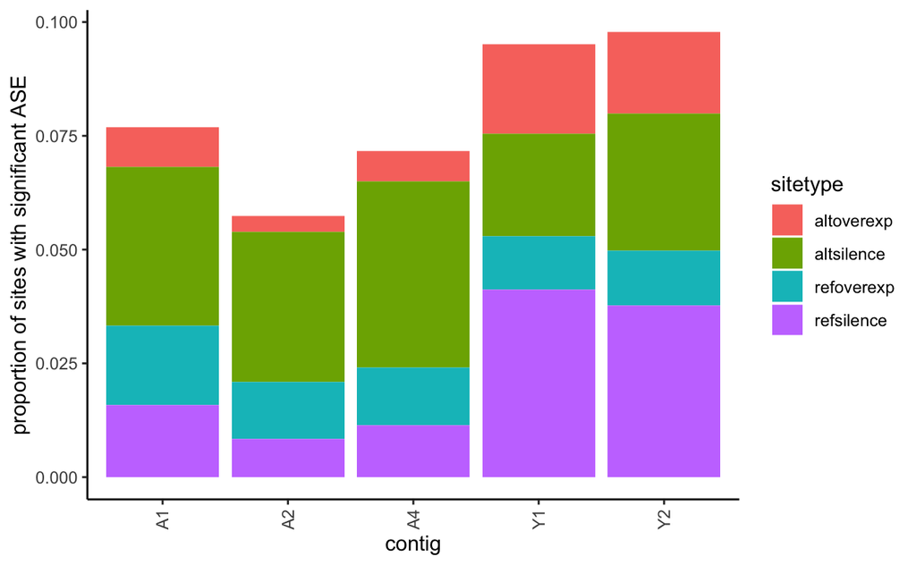

By sex-linked region (as defined in genome paper draft)

- Old sex-linked region has an extreme amount of Y silencing
- changing p value cut off to 0.1 doesn’t change the pattern much

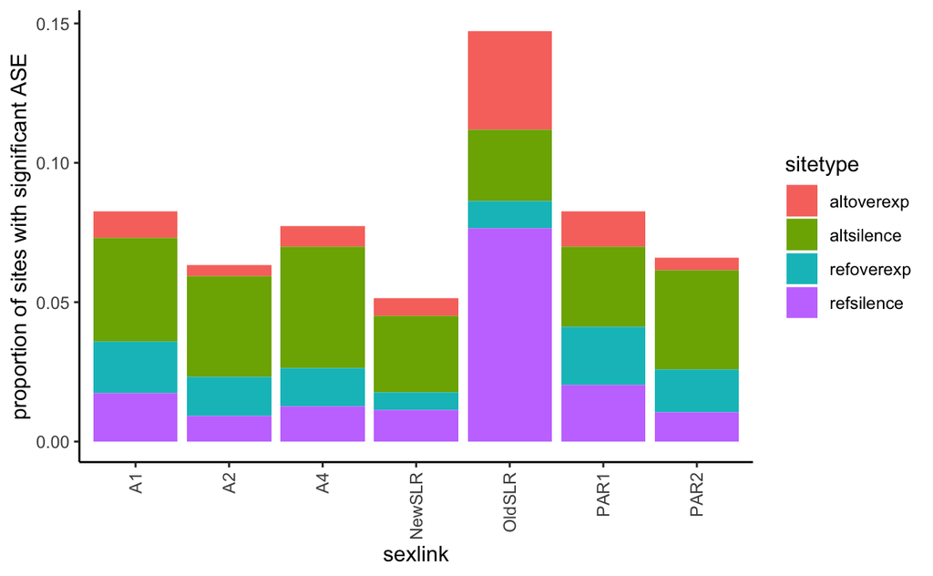

Plot position by ASE

```r
y2plotsig<-ggplot(filter(pvals,contig=="Y2",pbinomBH<0.1,pfisherBH<0.1), aes(position,rnarefratio)) +geom_point(aes(color=sexlink)) +geom_smooth() +theme_classic() ggsave("y1sigplot.png",plot=y1plotsig, width=7, height=5)
```

```
Error: unexpected symbol in "y2plotsig<-ggplot(filter(pvals,contig=="Y2",pbinomBH<0.1,pfisherBH<0.1), aes(position,rnarefratio)) +geom_point(aes(color=sexlink)) +geom_smooth() +theme_classic() ggsave"
```

### to do

- try plotting density of y-silenced snps
  - clustering?
- fraction of silenced (sig underexp) snps differ b/w sal origins??
- epigenetic silencing??? e.g. TEs - strata or TE lol